# 자연언어처리 8주차_텍스트 마이닝을 사용한 자연언어처리 #3: 토픽 모델링 및 TF-IDF

고려대학교 일반대학원 심리학과

2025년 10월 20일 월요일 4-5교시

# 0. 본 수업에 사용될 함수 미리보기

- 수업목표와 직접적으로 관련된 함수는 본문에서 상세히 소개.
- 함수의 상세한 사용법은 코드 주석 참조.

**[표 1] 본 수업에 사용될 함수 목록**

| 함수 | 출처 패키지 | 기능 |
| --- | --- | --- |
| adorn_ns() | janitor | 표에 빈도(n)를 추가 |
| adorn_percentages() | janitor | 비율 계산(행/열 기준) |
| adorn_pct_formatting() | janitor | 비율을 퍼센트 형식으로 포맷 |
| arrange() | tidyverse(dplyr) | 특정 열 기준으로 행 정렬 |
| corpus() | quanteda | 텍스트 데이터를 corpus 객체로 변환 |
| count() | tidyverse(dplyr) | 그룹별 빈도 계산 |
| dfm_tfidf() | quanteda | DFM 객체에서 TF-IDF 계산 |
| graph_from_adjacency_matrix() | igraph | 인접행렬로부터 그래프 생성 |
| inspect() | tm | DTM 구조 확인 |
| left_join() | tidyverse(dplyr) | 두 데이터프레임을 특정 칼럼 기준으로 병합 |
| mean() | R base | 평균 계산 |
| pivot_longer() | tidyverse(tidyr) | 열을 길게 변환(wide → long) |
| pivot_wider() | tidyverse(tidyr) | 열을 넓게 변환(long → wide) |
| posterior() | topicmodels | LDA 모델의 주제 분포 및 단어 확률 추출 |
| sim2() | text2vec | 문서 간 유사도(코사인 등) 계산 |
| slice_max() | tidyverse(dplyr) | 특정 열 기준으로 상위 행 선택 |
| slice_sample() | tidyverse(dplyr) | 무작위로 행 샘플링 |
| sort() | R base | 벡터 또는 행렬 정렬 |
| tabyl() | janitor | 빈도표 생성 |
| tokens() | quanteda | 텍스트를 토큰 단위로 분할 |
| topfeatures() | quanteda | DFM에서 가장 빈도가 높은 단어 추출 |

# 1. 토픽 모델링(topic modelling) 개관

- 개념
  - 방대한 문서 데이터에서 주제(topics)를 자동으로 찾아내는 비지도학습(unsupervised learning)[^1] 기법.
  - 컴퓨터가 자주 함께 등장하는 단어들의 묶음을 찾아내고, 이를 바탕으로 각 문서가 어떤 주제에 속하는지 추정.
    - 정치 주제: 국회, 선거, 대통령, 법안 같은 단어들이 자주 함께 나타남.
    - 경제 주제: 주식, 금리, 투자, 환율 같은 단어들이 자주 함께 나타남.
- 가정
  - 하나의 문서는 여러 주제의 혼합이다: “2024년 총선 결과가 주식시장에 미치는 영향”이라는 제목의 기사가 있다면, 이 문서는 “정치”와 “경제” 두 주제의 특성을 모두 가지고 있음.
  - 하나의 주제는 특정 단어들의 분포로 표현된다
    - “정치”라는 주제에선 “선거”라는 단어가 90퍼센트, “경제”라는 주제에선 5퍼센트, “스포츠”라는 주제에선 5퍼센트의 확률로 나타날 수 있음.
    - 각 주제를 구성하는 단어들의 목록과 그 주제에서 이들 단어가 나타날 확률을 파악하는 것이 핵심!

# 2. 잠재 디리클레 할당(latent Dirichlet allocation, LDA)

## (1) 제창자와 특징

- 제창자: 19세기 독일 수학자 러죈 디리클레(Lejeune Dirichlet, 1805-1859). 그가 제안한 디리클레 분포(Dirichlet distribution)를 이용해 문서에 잠재된 주제를 추론.
- 특징
  - 확률적 접근방식을 사용하는 대표적인 토픽 모델링 알고리즘.
  - 각 문서를 주제들(topics)의 집합 & 각 주제를 단어들의 집합으로 간주.
  - 각 주제와 연관된 단어들을 찾는 동시에 각 문서를 설명해주는 주제들을 판단함.
  - LDA에서 정의하는 주제: 주제 = 특정 단어들의 분포. [EX] 주제가 “경제학”이라면, 해당 주제일 때 높은 확률로 분포하는 단어들을 통해 특정 문서의 주제가 “경제학”인지 여부를 판단함.

## (2) 수행과정: 무지에서 통찰로

- **1. 초기 무작위 할당**
  - 일단 문서를 입력받으면 문서 내 각 단어를 임의로 여러 주제 중 하나에 배정함.
  - “주식”, “국회”, “정책”이라는 단어가 포함된 문서를 발견하면, 이 단어들을 무작위로 ‘주제 1’ 또는 ’주제 2’에 할당함. $\Rightarrow$ 무작위 주사위 던지기!
- **2. 반복적 추론**
  - 각 단어의 배정을 하나씩 다시 살피며, 이웃 단어들과의 관계를 기반으로 가장 논리에 부합하는 주제를 찾아냄. 이것이 바로 LDA의 핵심적인 학습과정!
  - 컨텍스트 분석: 모델은 “주식”이라는 단어가 “금리” 및 “투자”와 함께 자주 나타나는 것을 포착. 반면 “국회”라는 단어는 “선거” 및 “법안”과 함께 묶이는 경향이 있음을 발견.
  - 확률 업데이트: 이 관계를 바탕으로, 모형은 각 단어의 주제확률을 다시 계산하고 업데이트함. [EX] “주식”은 “경제” 주제에 속할 확률을 높임 & “국회”는 “정치” 주제에 속할 확률을 높임.
  - 위의 과정을 모든 단어에 대해 수없이 반복.
- **3. 수렴**
  - 충분한 반복학습을 거치면, 모형은 더 이상 단어의 주제배정을 크게 바꾸지 않음. 즉 확률이 안정적인 상태로 **수렴**하게 됨.
  - 이 단계에서 LDA는 두 가지 최종 결과물 도출
    - 결과물 1: 주제-단어 확률(이 주제는 어떤 단어들로 구성되어 있다). [EX] 주제 1(경제) $\Rightarrow$ “주식”, “금리”, “투자” 등의 단어 확률이 높음. 주제 2(정치) $\Rightarrow$ “국회”, “선거”, “법안” 등의 단어 확률이 높음.
    - 결과물 2: 문서-주제 확률(이 문서는 어떤 주제와 관련이 있다). [EX] 문서 29 $\Rightarrow$ “경제” 주제와 80페센트, “정치” 주제와 20퍼센트 관련됨. 문서 54 $\Rightarrow$ “경제” 주제와 5퍼센트, “정치 주제”와 95퍼센트 관련됨.

# 3. TF-IDF(term frequency-inverse document frequency)

- 개념: 개별 단어가 특정 문서에서 얼마나 중요한지를 수치화하는 방법.
- 단어 빈도(term frequency, TF)
  - 설명: 해당 단어가 문서에 몇 번 출현하는가?
  - 단점: 불용어의 경우 빈도는 높지만 중요도는 낮음.
- 역문서 빈도(inverse document frequency, IDF)
  - 설명: 문서마다 공통으로 자주 나타나는 단어의 가중치는 줄이고, 문서들에 자주 나타나지 않지 않는 단어의 가중치는 높임.
  - 공식
    - DF(*t*): 특정 단어 *t*가 등장한 문서의 수.
    - IDF(*d*, *t*): DF(*t*)의 역수. 단어 *t*의 희귀성을 측정하는 척도.
    - $IDF(단어)=ln(\frac{문서의\: 수}{해당\: 단어가\: 포함된\: 문서의 \:수})$
- 단어 빈도-역문서 빈도(term frequency-inverse document frequency, TF-IDF)
  - 설명
    - 단어가 말뭉치([EX] 논문초록 말뭉치) 내 특정 문서([EX] 논문 129번)에서 얼마나 중요성을 지니는지를 측정하기 위해 고안된 지수.
    - 문서 내 단어마다 중요도를 가중치로 부여.
  - 공식: TF와 IDF의 곱.

# 4. LDA vs. TF-IDF: 텍스트 분석에 대한 두 가지 다른 관점

- LDA: 문서의 주제 추론(주제 중심)
  - 관점: 문서 전체가 다양한 **주제들의 혼합**으로 이루어져 있다고 가정하고 그 주제들을 추론함.
  - 결과: 주제-단어 분포를 통해 “경제”나 “정치” 같은 추상적인 주제를 발견하고, 문서-주제 분포를 통해 각 문서가 어떤 주제에 속하는지를 파악함.
  - TF-IDF 결과 해석 보완
    - 문서 내에서 중요한 단어를 추출하는 데는 효과적. 그러나 그 단어가 어떤 맥락(주제)에서 중요한지는 알려주지 않음.
    - TF-IDF 키워드에 **주제 맥락** 부여.
- TF-IDF: 단어의 중요성 측정(개별 단어 중심)
  - 관점: 한 문서 내에서 단어의 상대적인 중요도를 측정하는 데 중점.
  - 결과: TF-IDF 점수가 높은 단어는 해당 문서의 핵심내용을 잘 나타내는 단어라고 간주 가능. [EX] 경제 기사에서는 “주식”, “환율” 같은 단어의 TF-IDF 점수가 높게 측정될 것.
  - LDA 결과 해석 보완
    - LDA는 각 주제를 대표하는 단어들을 확률분포로 보여줄 뿐([EX] “정치” 주제는 “선거”, “국회” 같은 단어들의 확률이 높음), 그것이 실제로 얼마나 중요한 단어인지는 말해주지 않음.
    - 특정 주제를 대표하는 **단어들의 중요도** 확인.
- LDA와 TF-IDF의 상호보완
  - TF-IDF는 미시적 관점에서 **이 문서의 핵심단어는 무엇인가?**에 답하는 반면, LDA는 거시적 관점에서 **이 문서들이 공통적으로 다루는 주제는 무엇인가?**에 답함.
  - 두 기법의 결과를 결합하면, “전체 문서집합에서 가장 중요한 주제는 무엇이고(LDA), 그 주제를 가장 잘 대표하는 희귀하고 중요한 단어는 무엇인가(TF-IDF)”라는 더 깊이 있는 질문에 답할 수 있음.
  - 방법
    - 개별 문서의 중요 단어(TF-IDF) 파악: [EX] 논문초록 말뭉치 내 문서 129번에서 추출된 주요 단어가 “경제”, “주식”, “시장”, “정책”이었음 $\rightarrow$ 이 문서가 **이러한 단어들**을 핵심적으로 다루고 있구나!
    - 해당 문서가 속한 주제의 맥락(LDA) 이해. [EX] 논문초록 말뭉치 내 문서 129번은 주제 2(경제)로 분류 & 출현확률이 높은 단어가 “주식”, “투자”, “금리”, “시장”이었음 $\rightarrow$ 이 문서는 “경제”라는 주제와 관련이 깊고, 해당 주제는 주로 이런 단어들로 구성되는구나!

**[표 2] TF-IDF와 LDA: 텍스트 분석에 대한 두 가지 관점 비교**

| 구분 | TF-IDF | LDA |
| --- | --- | --- |
| 기반 텍스트 | 개별 문서 | 전체 말뭉치 |
| 분석단위 | 개별 **단어**의 중요성 | 문서에 숨겨진 **주제** |
| 목표 | 특정 문서에서 단어가 얼마나 중요한지 점수화 | 문서 집합에 숨겨진 주제 발견 및 추론 |
| 결과 | 단어별 중요도 점수 | 문서별 주제 확률 및 주제별 단어 확률(분포) |
| 주요 활용 | 핵심 키워드 추출, 검색 엔진, 문서 유사도 | 주제분류, 문서 군집화, 텍스트 요약 |
| 관점 | **단어**가 문서의 가치를 결정하는 ‘도구’ | **주제**가 단어와 문서를 연결하는 ‘중심’ |

# 5. LDA 수행하기

## (1) 텍스트 전처리하기

- 모델링용 텍스트 데이터셋
  - AI Hub 논문자료 요약 데이터(2020년 공개): 메타데이터(저자, 제목, 발행처, 발행년, 학술분류 등), 전체 내용에 대한 요약(논문초록), 섹션별 요약(논문의 핵심문단 요약문) 등의 컨텐츠가 JSON 파일 형태로 저장.
  - 구성: 총 6개의 JSON 파일(총 350,000개 초록 수록)로 구성. 본 수업에서는 “논문요약_0206_0.JSON” 파일(총 32,000개 초록 수록)만 사용.
  - 학문분야: 인문학, 사회과학, 자연과학, 공학, 의약학, 농수해양학, 예술체육학, 복합학. $\Rightarrow$ 결과해석의 용이성을 위해 이 중에서 인문학, 공학, 의약학 분야만 선택.
- 모델링 결과의 질을 높이기 위해서는 데이터셋에 대한 세심한 전처리가 요구됨. 특히 문서의 수가 많을수록 더 중요!
- 전처리 절차: 형태소 분석 $\rightarrow$ 토큰화 $\rightarrow$ 정규화 $\rightarrow$ 불용어 제거 $\rightarrow$ 문서번호와 문서정보만 남기기.
- 분야별 동수 무작위 추출
  - 주제편향: 문서의 수가 많은 분야의 단어들이 주제를 지배할 수 있음.
  - 희소주제: 문서의 수가 적은 분야는 주제가 제대로 형성되지 않을 수 있음.
  - 무작위 추출: 상술한 두 문제를 방지하기 위해 세 분야의 논문초록을 각 400개씩 무작위 추출.

### 1) 말뭉치 불러들여 분야별 동수 문서 무작위 추출하기

- 말뭉치 파일 다운로드하기.

```r
library(googledrive) # 구글 드라이브에 저장된 파일 공유 링크 통해 다운로드하는 데 필요한 패키지 불러오기(없으면 설치)

# 인증 해제하기(공유된 공개 파일일 경우).
drive_deauth()

# 다운로드할 파일을 저장할 폴더 만들기.
dir.create("texts/topicmodels")

# "article_summary_0206_0.zip" 압축파일 구글 드라이브에서 다운로드하기.
lda_url_id <- "1sf8BdRzjouUnfDrKiqE15cXb29hx9uEX"

# 내보낼 로컬 경로 지정하기.
local_path <- "texts/topicmodels/article_summary_0206_0.zip"

# 파일 다운로드하기.
drive_download(as_id(lda_url_id), path = local_path, overwrite = TRUE)

# 다운로드한 압축파일 texts/topicmodels 폴더에 압축 풀기.
unzip("texts/topicmodels/article_summary_0206_0.zip", exdir = "texts/topicmodels")
```

- JSON 형식의 말뭉치 파일 R로 불러들여 분석에 필요한 컨텐츠 정리하기.

```r
library(tidyverse)
library(jsonlite) # JSON 파일을 R로 불러들이는 패키지 불러오기.

# JSON 파일 데이터 프레임 형식으로 불러들이기.
article <- fromJSON("texts/topicmodels/article_summary_0206_0.json", simplifyDataFrame =T)

# 데이터의 구조 살펴보기(주요 정보는 data 섹션에 들어 있음).
attributes(article)
```

```
## $names
## [1] "totalcount" "data"
```

```r
# data 섹션만 추출하여 티블 형식으로 변환하기.
set.seed(123) # 난수 고정하기.
article.2 <- article$data %>%
  as_tibble() %>% # 티블 형식으로 변환하기.
  unnest() %>% # 리스트를 행으로 모두 펼치기.
  filter(doc_type == "논문", # 문서유형이 논문인 행만 추출하기.
         ipc %in% c("공학", "인문학", "의약학")) %>% # 학문분야가 공학, 인문학, 의약학인 행만 추출하기.
  group_by(ipc) %>% # 세 개의 학문분야별로 그룹화하기.
  slice_sample(n=400) %>% # 학문분야 그룹별로 400개씩 무작위 추출하기.
  ungroup() %>% # 그룹화 해제하기.
  select(ipc, doc_id, orginal_text) %>% # LDA에 필요한 문서 식별자(doc_id)와 초록 텍스트(orginal_text) 칼럼 + 문서의 주제(ipc)만 남기기.
  rename(actual_label = ipc) # 문서의 주제 ipc를 좀더 직관적인 이름인 actual_label로 수정하기.
article.2
```

```
## # A tibble: 1,200 × 3
##    actual_label doc_id
##    <chr>        <chr>
##  1 공학         A201008192866
##  2 공학         A201008192914
##  3 공학         A201008192630
##  4 공학         A201008183004
##  5 공학         A201008194895
##  6 공학         A201008193389
##  7 공학         A201008192227
##  8 공학         A201008191392
##  9 공학         A201008193774
## 10 공학         A201008199791
##    orginal_text
##    <chr>
##  1 본 논문에서는 윤곽선의 순열을 기반으로 하여 형상 시그너쳐를 추출하고, 주도적 특징을 기반으로 형상 정열 및 정규화한 뒤, 기존 절대각도…
##  2 본 논문은 H.264 움직임 예측을 위해 휘도 성분과 색차 성분의 부화소를 생성하는 효율적인 부화소 보간기 회로 설계에 대해 기술한다. …
##  3 국가의 브랜드 파워와 국가 이미지를 강화시킬 수 있는 문화원천으로 판단되는 신한류는 꾸준한 경제적 파급효과를 가져올 것으로 예상됨에 따라…
##  4 본 연구에서는 Navier-Stokes solver에 기초한 3차원혼상류해석법인 TWOPM-3D를 적용하여 고립파와 연안교량과의 상호작용…
##  5 본 논문에서는 변단면 기능경사재료 보에서 중립면 탄성계수가 축방향을 따라 공간적 불확실성을 가질 경우에 대한 구조 응답변화도 산정을 위한…
##  6 유아용 체감형 게임은 유아 놀이 공간 축소로 인한 안전한 유아 놀이 공간 부족에 대한 해결책 중 하나로 대두되고 있다. 이에 따라 본 연…
##  7 고도화된 정보통신 기술에 부합하는 사용자-친화적인 서비스 제공을 위해서 많은 정보가 무분별하게 수집되고 있다. 최근 사용자 정보 관리의 …
##  8 사물 인터넷 서비스를 실현하기 위해서는 확장성을 고려한 센싱 데이터 관리 및 서비스 구축이 필요하다. 그러나 기존 사물 인터넷 서비스들은…
##  9 비소는 음이온적인 거동을 가지고 Eh-pH의 조건에 따라 특성이 변화하여 비소로 오염된 토양을 정화하기 위한 방법이 확립되어있지 못한 실…
## 10 본 논문은 유비쿼터스 컴퓨팅 시대의 등장이 인간의 정보기술 활용욕구의 발전단계에 따라 필연적으로 등장한 새로운 정보기술 패러다임이며, 지…
## # ℹ 1,190 more rows
```

### 2) 토큰화 및 불용어 제거

- 토큰화: 학술논문은 대부분 명사가 키워드가 되므로, 형태소 분석 후 명사 중심으로 토큰화하기.
- 불용어: “논문”, “연구”, “본고”는 정보값이 적으면서 대부분의 논문에 걸쳐 반복되므로 제거하기.

```r
library(reticulate) # 가상환경 생성 패키지 로드하기.

use_condaenv("my_env") # 가상환경 불러오기.

# kiwipiepy 라이브러리에서 'Kiwi'라는 분석기 클래스를 불러와 초기화하기
kiwi <- import("kiwipiepy")$Kiwi()

# kiwipiepy의 analyze() 분석기로 문서별 명사 형태소 분석 함수 만들기.
analyze_nng_kiwi <- function(text) {
  # kiwipiepy의 analyze() 함수로 분석하기.
  results <- kiwi$analyze(text)

  # purrr 패키지의 map_chr 함수를 사용해 파이썬 객체에서 형태소와 품사 태그 추출.
  # .x는 각 형태소 객체를 의미하며, '$form'과 '$tag'로 내용(문자열 벡터)을 가져옴.
  tagged_tokens <- map_dfr(results[[1]][[1]], ~tibble(
    morph = .x$form, # 형태소 추출.
    pos = .x$tag # 품사 추출.
  ))
  # 불용어 정의하기.
  stop_words_article <- c("논문", "연구", "본고")
  filtered_tokens <- tagged_tokens %>%
    filter(str_detect(pos, "NNG|NNP")) %>% # 일반명사, 고유명사만 추출하기
    filter(!morph %in% stop_words_article)
  return(list(nng = filtered_tokens$morph)) # 필터링된 토큰(일반명사 & 고유명사) 리스트 만들기. 리스트 내 요소들에 대한 명명은 nng로!
}

# 일괄적으로 문서별로 명사(NNG, NNP)만 필터링하기.
article_filtered <- article.2 %>%
  mutate(pos_result = map(orginal_text, analyze_nng_kiwi)) %>% # text 칼럼에 대해 analyze_nng_kiwi() 함수로 일괄 형태소 분석한 뒤 pos_result 칼럼에 저장하기.
  mutate(text = map_chr(pos_result, ~ str_c(.x$nng, collapse = " "))) %>% # pos_result(일반명사와 고유명사로 이루어진 리스트)를 띄어쓰기 단위로 이어붙이기.
  select(-pos_result, -orginal_text) # 불필요한 칼럼 제거하기.

save(article_filtered, file="article_filtered.rda")
```

## (2) 문서-용어 매트릭스(document-term matrix, DTM)

### 1) 소개

- 설명
  - **topicmodels**를 비롯한 대부분의 텍스트 마이닝 패키지가 선호하는 데이터 구조.
  - 특징
    - 각 행은 하나의 문서([EX] 논문, 기사, 리뷰, 게시글 등)를 나타냄.
    - 각 열은 하나의 용어(term)를 나타냄.
    - DTM 값은 문서에 용어가 나타난 횟수를 가리킴.
    - 그러나 대부분의 문서-단어 쌍은 빈도가 0에 수렴함. [EX] 연예 주제에서도 “필립 세이무어 호프먼”이라는 용어가 나타난 문서는 매우 희귀할 것.
- DTM 생성용 패키지 및 함수
  - **tidytext**
    - 특징: 소규모 데이터셋 모델링에 적합.
    - 함수: `cast_dtm()`.
    - 논항
      - `data`: 문서 식별자, 토큰, 문서당 토큰 빈도로 이뤄진 데이터프레임.
      - `document`: 문서 식별자 칼럼 이름.
      - `term`: 토큰 칼럼 이름.
      - `weight`: 문서당 토큰 빈도.
  - **quanteda**
    - 특징: 대규모 데이터셋 모델링에 적합.
    - 함수 1
      - `corpus()`: 문서집합 생성용. `tokens()`의 입력이 됨.
      - 논항
        - `x`: 문서 식별자와 토큰으로 이뤄진 데이터프레임.
        - `text_field`: 토큰 칼럼 이름.
        - `docid_field`: 문서 식별자 칼럼 이름.
    - 함수 2
      - `tokens()`: 문서집합 토큰화용. `dfm()` 함수의 입력이 됨.
      - 논항
        - `x`: 토큰화할 대상. 일반적으로 corpus 객체.
        - `what`: 토큰화 단위. “word”(기본값), “sentence”, “character” 등.
        - `remove_punct`: 문장부호 제거 여부(`TRUE`/`FALSE`).
        - `remove_symbols`: 기호([EX] ©, ™) 제거 여부(`TRUE`/`FALSE`).
        - `remove_numbers`: 숫자 제거 여부(`TRUE`/`FALSE`).
        - `remove_url`: URL 제거 여부(`TRUE`/`FALSE`).
        - `remove_separators`: 공백, 줄바꿈 등 구분자 제거 여부(`TRUE`/`FALSE`).
        - `split_hyphens`: 하이픈(-)으로 연결된 단어를 분리할지 여부(`TRUE`/`FALSE`).
        - `include_docvars`: 문서변수(`docvars`: 문서에 대한 메타정보를 담고 있는 변수들. [EX] 문서 식별자, 분야, 날짜, 저자, 출처, 카테고리 등)를 유지할지 여부(`TRUE`/`FALSE`).
        - `verbose`: 처리과정을 콘솔에 출력할지 여부(`TRUE`/`FALSE`).
    - 함수 3
      - `dfm()`: DTM 객체 색성용.
      - 논항: `x` $\Rightarrow$ `tokens()` 함수로 생성된 토큰화된 문서집합.
    - 함수사용 순서: `corpus()` $\rightarrow$ `tokens()` $\rightarrow$ `dfm()`.

### 2) 간단한 DTM 생성 실습

#### A. **tidytext** 패키지를 활용하여 DTM 객체 생성하기

```r
library(tidytext)
library(tm)

# 원시 텍스트 벡터 생성하기.
text <- c("바나나는 꼭지가 있어요", "바나나는 껍질이 있어요")

# 문서 ID 부여하기.
text_df <- tibble(document = str_c("doc_", 1:2), text = text) # 칼럼이 document와 text인 티블 생성하기.

# DTM 객체 생성하기.
dtm_tidy <- text_df %>%
  unnest_tokens(word, text, token = "words") %>% # 띄어쓰기 단위로 text 토큰화하여 word 칼럼에 저장하기.
  count(document, word) %>% # 각 문서별로 토큰의 빈도 계산하기.
  cast_dtm(document, word, n) # 문서 식별자, 토큰, 문서당 토큰 빈도를 cast_dtm() 함수에 넣어 DTM 객체 생성하기.

# DTM 구조 확인하기.
dtm_tidy
```

```
## <<DocumentTermMatrix (documents: 2, terms: 4)>>
## Non-/sparse entries: 6/2
## Sparsity           : 25%
## Maximal term length: 4
## Weighting          : term frequency (tf)
```

```r
# DTM 내부 행렬 보기.
inspect(dtm_tidy)
```

```
## <<DocumentTermMatrix (documents: 2, terms: 4)>>
## Non-/sparse entries: 6/2
## Sparsity           : 25%
## Maximal term length: 4
## Weighting          : term frequency (tf)
## Sample             :
##        Terms
## Docs    껍질이 꼭지가 바나나는 있어요
##   doc_1      0      1        1      1
##   doc_2      1      0        1      1
```

- 출력 해석
  - Non-/sparse entries: 0이 아닌 값(non)과 0인 값(sparse)의 개수. [EX] 6/2 $\Rightarrow$ 총 8개의 셀 중 6개는 단어가 등장했고, 2개는 등장하지 않음.
  - Sparsity: 전체 셀 중 0의 비율(%). [EX] 25% $\Rightarrow$ 전체 행렬의 25%가 0으로 채워져 있음
  - Maximal term length: 가장 긴 단어의 문자 수. [EX] 4 $\Rightarrow$ 가장 긴 단어가 네 글자.
  - Weighting 셀 값의 의미: 빈도, TF-IDFf 등. [EX] term frequency(tf) $\Rightarrow$ 각 셀은 해당 문서에서 단어가 등장한 횟수를 의미함.

#### B. **quanteda** 패키지를 활용하여 DFM(document-feature matrix) 객체 생성하기

```r
library(quanteda)

# 문서집합 객체 생성하기.
corpus_obj <- corpus(text_df, text_field = "text", docid_field = "document")

# 토큰화하기.
tokens_obj <- tokens(corpus_obj, remove_punct = TRUE)

# DFM 생성하기.
dfm_obj <- dfm(tokens_obj)

# DFM 구조 확인하기.
dfm_obj
```

```
## Document-feature matrix of: 2 documents, 4 features (25.00% sparse) and 0 docvars.
##        features
## docs    바나나는 꼭지가 있어요 껍질이
##   doc_1        1      1      1      0
##   doc_2        1      0      1      1
```

```r
# DFM에서 가장 많이 등장한 토큰 보기.
topfeatures(dfm_obj)
```

```
## 바나나는   있어요   꼭지가   껍질이
##        2        2        1        1
```

### 3) 모델링에 투입할 DTM 생성 실습

- **tidytext**패키지를 활용하여 DTM 객체 생성하기

```r
download.file(
  url = "https://raw.githubusercontent.com/cognitivepsychology/NLP_2025/main/article_filtered.rda",
  destfile = "article_filtered.rda",
  mode = "wb"  # 바이너리 파일이므로 반드시 "wb"로 설정하기.
)

load("article_filtered.rda") # article_filtered 객체 로드하기.

# cast_dtm() 함수로 논문초록 DTM 객체 생성하기.
article_dtm_tidy <- article_filtered %>%
  unnest_tokens(word, text, token = "words") %>% # 띄어쓰기 단위로 text 토큰화하여 word 칼럼에 저장하기.
  count(doc_id, word) %>% # 각 문서별로 토큰의 빈도 계산하기.
  cast_dtm(doc_id, word, n) # 문서 식별자, 토큰, 문서당 토큰 빈도를 cast_dtm() 함수에 넣어 DTM 객체 생성하기.
article_dtm_tidy
```

```
## <<DocumentTermMatrix (documents: 1200, terms: 11575)>>
## Non-/sparse entries: 79471/13810529
## Sparsity           : 99%
## Maximal term length: 11
## Weighting          : term frequency (tf)
```

- **quanteda**패키지를 활용하여 DTM 객체 생성하기

```r
# 문서집합 객체 생성하기.
article_corpus <- corpus(article_filtered, text_field = "text", docid_field = "doc_id")

# 문서집합 객체 토큰화하기.
article_corpus_token <- tokens(article_corpus, remove_punct = TRUE, remove_symbols = TRUE)

# dfm() 함수로 논문초록 DTM 객체 생성하기.
article_dtm_quanteda  <- dfm(article_corpus_token)
article_dtm_quanteda
```

```
## Document-feature matrix of: 1,200 documents, 11,575 features (99.43% sparse) and 1 docvar.
##                features
## docs            윤곽선 순열 기반 형상 시그너쳐 추출 주도 특징 정열 정규
##   A201008192866      1    1    3    5        1    1    1    1    1    1
##   A201008192914      0    0    1    0        0    0    0    0    0    0
##   A201008192630      0    0    0    0        0    0    0    0    0    0
##   A201008183004      0    0    0    0        0    0    0    0    0    0
##   A201008194895      0    0    0    0        0    0    0    0    0    0
##   A201008193389      0    0    0    0        0    0    0    0    0    0
## [ reached max_ndoc ... 1,194 more documents, reached max_nfeat ... 11,565 more features ]
```

### 4) **topicmodels** 패키지의 `LDA()` 함수로 LDA 모형 생성하기

#### A. `LDA()` 함수의 주요 논항

- `x`: `DocumentTermMatrix` 객체.
- `k`
  - 사용자가 지정하는 주제의 수.
  - 실제 주제의 수를 알지 못할 경우, `k` 값을 조금씩 올려가며 최적의 주제 수를 찾아갈 것을 권장.
- `method`
  - 모형추정 방법: 선택지는 `VEM(variational expectation-maximization)`또는 `Gibbs`. `VEM`이 디폴트값임.
  - `VEM`
    - 모든 가능성을 계산해서 가장 좋은 추정치를 찾아감.
    - 빠른 결과가 필요할 때 추천.
  - `Gibbs`
    - 가능한 모든 경우들을 하나씩 뽑아보면서 전체 분포를 파악해나감.
    - 데이터가 희소/복잡할 때 추천.
    - 학습용 실습에 적절. 직관적이고 해석이 쉬움.
- `control = list()`: 모형추정을 위한 통제용 매개변수 리스트.
  - `alpha`(α)
    - 문서의 주제 분포 생성을 위한 디리클레 분포 초매개변수(hyperparameter: 인간이 지정하는 매개변수)에 해당.
    - 시작 값은 주로 50/k로 잡음. 1에 가까워질수록 문서에 많은 주제 포함.
  - `beta`(β)
    - 주제의 단어 분포 생성을 위한 디리클레 분포 초매개변수(단, 여기선 논항으로 투입되지 않음)에 해당.
    - 1에 가까워질수록 주제에 많은 단어 포함.
  - `estimate.alpha`: `alpha`를 추정할 것인지 여부. 선택지 = `TRUE` 또는 `FALSE`.
  - `estimate.beta`: `beta`를 추정할 것인지 여부. 선택지 = `TRUE` 또는 `FALSE`.
  - `seed`
    - 난수생성을 위한 seed를 고정하는 경우. 특정 숫자로 맞춰두면 초기 주제분포를 고정된 방식으로 설정 가능.
    - `Sys.time()` 함수(디폴트값)를 사용하면 현재 시각에 맞추어 난수가 생성되므로 재현(reproductability) 불가.
  - `verbose`: 진행상황 출력 여부. 선택지 = `TRUE` 또는 `FALSE`.
  - `best`: 최적의 모형 선택 여부. 선택지 = `TRUE` 또는 `FALSE`. `best = TRUE`이면 로그-우도(log-likelihood) 값에 비추었을 때 최상의 모형만 반환해줌.
  - `VEM` 샘플링 선택 시
    - `nstart`
      - 무작위 초기화(initialization)를 위한 반복수행 횟수.
      - `nstart` = x면, LDA 모형을 x번 서로 다른 초기값으로 반복 실행하겠다는 의미.
      - LDA는 초기값에 따라 결과가 달라질 수 있음. 디폴트값이 1이므로, 2 이상으로 지정하는 것이 좋음.
      - 각 실행은 서로 다른 초기 주제분포에서 시작되며, 그중에서도 최적의 수렴 모형을 선택해줌.
    - `initialize`(`VEM` 선택 시에만 설정)
      - 주제들이 초기화되는 방식 결정. 선택지 $\Rightarrow$ `random`, `seeded`, `model`.
      - `random`: 무작위 초기화. 초기에 문서와 단어를 주제에 무작위로 할당하는 것.
      - `seeded`
        - seed 설정 초기화. 초기에 문서와 단어를 주제에 할당할 때 “문서별 단어 분포”에 기반해 고정된 방식으로 할당하는 것.
        - 고정된 알고리즘에 따라 결정되므로 재현 가능성이 높아짐.
      - `model`: 기존의 적합화(fitting)에 사용된 모형이 제공되어야 함. 기존 모형을 따로 제공하지 않는 경우 무작위 초기화가 기본값임.
  - `Gibbs` 샘플링 선택 시
    - `iter`: 총 샘플링 횟수. 얼마나 반복해서 샘플을 뽑을지 결정.
    - `burnin`: 초기 샘플을 버리는 단계. 모형이 안정되기 전까지의 초기 샘플(초기 불안정 구간)을 제거.
    - `thin`: 샘플 간 간격. [EX] `thin = 100`이면 100번마다 한 개의 샘플 저장. 샘플 간 간섭을 줄여서 독립적인 샘플 확보.
    - 예시: `burnin = 1000` & `iter = 2000` & `thin = 100` $\Rightarrow$ 샘플링을 2000번 반복하면서 첫 1000번은 버리고 100번마다 한 개씩 샘플 저장 $\rightarrow$ 총 10개의 샘플이 최종 사용됨.
    - 추천
      - 시험용으로 빠른 결과를 원할 때: `burnin = 500`, `iter = 1000`, `thin = 50`.
      - 안정적 결과를 원할 때: `burnin = 1000`, `iter = 3000`, `thin = 100`.
      - 고품질 모델링을 원할 때: `burnin = 2000`, `iter = 5000`, `thin = 100~200`.

> LDA(x, k, method = “VEM”, control = list(estimate.alpha = TRUE, alpha = 50/k, estimate.beta = TRUE, seed = as.integer(Sys.time()), nstart = 1, best = TRUE, initialize = “random”, burnin = 정수, iter = 정수, thin = 정수))

#### B. LDA 실행하기

##### 가. `LDA()` 함수로 LDA 실행하기

- `LDA()` 함수로 3-주제 LDA 모형 생성하기: 우리가 선정한 학문분야는 총 세 가지임. 이에 따라 실제로 `k = 3`일 때 모형이 어떻게 구현되는지 살펴보기.

```r
library(topicmodels)

# 3-주제 LDA 모형 생성하기.
article_lda <- LDA(article_dtm_quanteda, k = 3, method = "Gibbs",
                   control = list(seed = 1234, # seed를 고정하면 다음에도 똑같은 결과를 재현할 수 있음.
                                  burnin = 1000,
                                  iter = 2000,
                                  thin = 100,
                                  best = TRUE)) # 실제 작업 시에는 verbose = TRUE 논항 추가 가능.
```

##### 나. 단어-주제 확률

###### a. 단어별 β 계산하기

- `tidy()` 함수: 통계모형 객체(여기서는 LDA 객체)를 tidy 형식으로 바꿔주는 **broom** 패키지 유래 함수.
- β
  - 특정 단어가 특정 주제에 할당될 확률: “모든 주제는 단어들이 무작위로 섞인 임의의 혼합물이다.”
  - `matrix` = “beta”를 지정해주면 주제, 단어, β 값이 제시됨.
  - β 값이 높은 단어일수록 그 주제를 대표하는 키워드일 확률이 높음.

```r
library(broom)
# install.packages("reshape2") 해당 패키지 첫 사용자는 reshape2 패키지가 없다는 메시지가 나오므로 미리 설치해둘 것.
abstract_topics <- tidy(article_lda, matrix = "beta")
abstract_topics
```

```
## # A tibble: 34,725 × 3
##    topic term         beta
##    <int> <chr>       <dbl>
##  1     1 윤곽선 0.00000199
##  2     2 윤곽선 0.000154
##  3     3 윤곽선 0.00000206
##  4     1 순열   0.00000199
##  5     2 순열   0.00000217
##  6     3 순열   0.0000226
##  7     1 기반   0.0000617
##  8     2 기반   0.00802
##  9     3 기반   0.00000206
## 10     1 형상   0.000798
## # ℹ 34,715 more rows
```

```r
# 주제별 최빈 단어 10개 확인하기: 티블 버전.
abs_top_terms <- abstract_topics %>%
  group_by(topic) %>% # 주제별로 그룹화하기.
  slice_max(beta, n = 10) %>% # 상위빈도 10개 단어만 추출하기.
  ungroup() %>% # 그룹화 풀기.
  arrange(topic, -beta) # 주제 오름차순, 베타 내림차순으로 배열하기.
abs_top_terms
```

```
## # A tibble: 31 × 3
##    topic term     beta
##    <int> <chr>   <dbl>
##  1     1 교육  0.00868
##  2     1 사회  0.00802
##  3     1 의미  0.00715
##  4     1 문제  0.00601
##  5     1 점    0.00572
##  6     1 중심  0.00518
##  7     1 존재  0.00516
##  8     1 관계  0.00510
##  9     1 문학  0.00494
## 10     1 과정  0.00490
## # ℹ 21 more rows
```

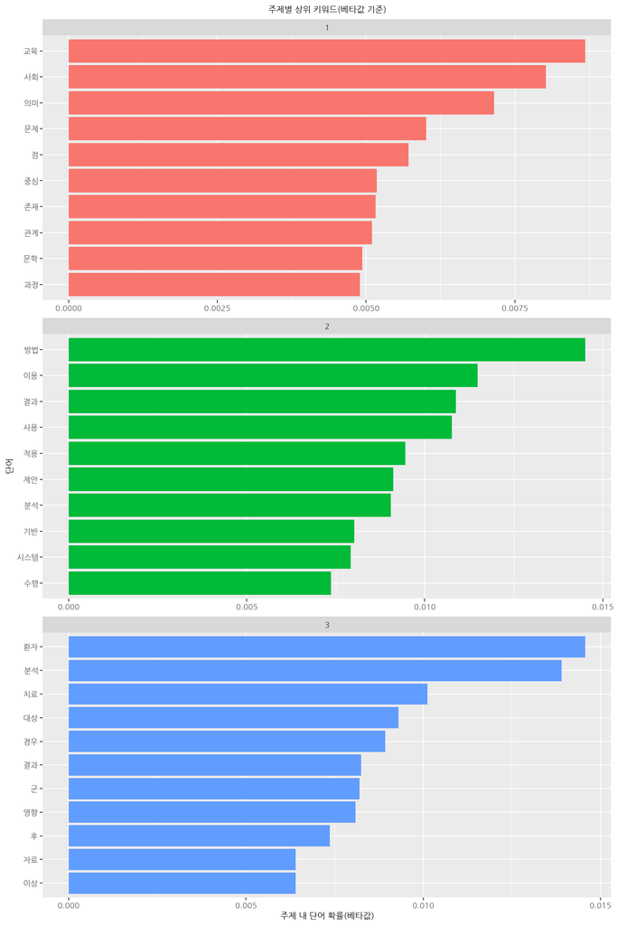

```r
#install.packages("showtext")
library(showtext)

# 폰트 등록: 시스템 경로 또는 Google Fonts(매번 새로운 세션마다 등록해주어야 함)
# font_add("AppleGothic", regular = "/System/Library/Fonts/Supplemental/AppleGothic.ttf") # 맥 사용자: 예시일 뿐이므로 font book 앱을 통해 직접 확인할 것.
font_add("NanumGothic", regular = "C:/Windows/Fonts/NanumGothic.ttf") # 윈도우 사용자

# showtext 활성화
showtext_auto()

# 주제별 최빈 단어 10개 확인하기: 시각화 버전.
abs_top_terms_plot <- abs_top_terms %>%
  ggplot(aes(x = reorder_within(term, beta, topic), y = beta, fill = factor(topic))) + # reorder_within(재배열할 벡터, 재배열의 기준이 될 벡터, 다면출력에 사용될 벡터). topic 값이 숫자로 되어 있으므로 factor 형식(주제 1, 주제 2, 주제 3)으로 바꾸기.
  geom_col(show.legend = FALSE, width = 0.9) + # 막대 그래프 형식으로 결괏값 제시. 범례는 제시하지 않음.
  facet_wrap(~ topic, scales = "free", ncol = 1) + # 다면출력은 topic(주제 1, 주제 2, 주제 3)을 기준으로. 척도는 규정하지 않음. 일렬로 보여주기.
  theme(strip.text=element_text(size=14)) + # 다면출력 표제 텍스트 크기 지정하기.
  scale_x_reordered() + # x축 단어가 "치료__1"처럼 단어와 주제가 서로 붙은 채로 제시되지 않도록 해줌.
  coord_flip() + # x축과 y축을 서로 뒤바꾸기.
  labs(title = "주제별 상위 키워드(베타값 기준)",
       x = "단어",
       y = "주제 내 단어 확률(베타값)") +
  theme(text= element_text(family = "NanumGothic"), # 텍스트 폰트 지정하기.
        axis.text.x = element_text(size = 14),  # x축 텍스트 크기.
        axis.text.y = element_text(size = 14),  # y축 텍스트 크기.
        axis.title.x = element_text(size = 16),  # x축 제목 크기.
        axis.title.y = element_text(size = 16),  # y축 제목 크기.
        plot.title = element_text(size = 16, face = "bold", hjust = 0.5) # 그래프 제목 크기 설정하기, 굵게 하기, 가운데 정렬하기.
        )
abs_top_terms_plot
```

###### b.주제 간 β 값 차이(로그비) 계산하기

- 두 주제 간에 β 값이 가장 큰 차이를 나타내는 단어 확인하기
  - 의의: 어떤 단어가 어느 주제에 특징적으로/배타적으로 나타나는지 확인 가능.
  - 추정방법
    - 두 β 값의 로그비로 계산. $\rightarrow$ $log_2(\frac{β_2}{β_1})$.
    - $β_2$가 두 배 높으면 로그비 = 1, $β_1$이 두 배 높으면 로그비 = -1.
  - 상대적으로 빈도가 지나치게 낮은 단어들은 제외: 적어도 한 주제에서 $β>\frac{1}{1000}$인 단어만 추출하기.

```r
# 로그비 계산하기.
abstract_beta <- abstract_topics %>%
  mutate(topic = str_c("topic", topic)) %>% # 숫자(1, 2, 3)로 되어 있는 topic 번호 앞에 "topic"을 붙여 topic1, topic2, topic3과 같이 수정함.
  pivot_wider(names_from = topic, values_from = beta) %>% # topic1, topic2, topic3이 별도의 열이 되고 그 행은 β 값이 차지하도록 티블의 구조를 변경함.
  filter(topic1 > .001 | topic2 > .001) %>% # 각 topic의 β 값이 0.001 이상인 행만 추출하기.
  mutate(log_ratio = log2(topic2 / topic1)) # 로그비 계산하기.
abstract_beta
```

```
## # A tibble: 370 × 5
##    term      topic1     topic2     topic3 log_ratio
##    <chr>      <dbl>      <dbl>      <dbl>     <dbl>
##  1 기반  0.0000617  0.00802    0.00000206      7.02
##  2 추출  0.00000199 0.00218    0.00000206     10.1
##  3 특징  0.00241    0.000937   0.000208       -1.36
##  4 기존  0.00000199 0.00644    0.00000206     11.7
##  5 관계  0.00510    0.00000217 0.00261       -11.2
##  6 이용  0.00000199 0.0115     0.00144        12.5
##  7 중심  0.00518    0.00000217 0.00000206    -11.2
##  8 값    0.00000199 0.00313    0.00000206     10.6
##  9 제안  0.00000199 0.00911    0.00000206     12.2
## 10 비교  0.00000199 0.00435    0.00278        11.1
## # ℹ 360 more rows
```

```r
# topic1 vs. topic2, topic1 vs. topic3, topic2 vs. topic3, 로그비 계산하기.
abstract_beta.1 <- abstract_beta %>%
  mutate(log_ratio_1_2 = log(topic1 / topic2), # topic1 vs. topic2 로그비.
         log_ratio_1_3 = log(topic1 / topic3), # topic1 vs. topic3 로그비.
         log_ratio_2_3 = log(topic2 / topic3)) # topic2 vs. topic3 로그비.

# 예시: topic1 vs. topic2 비교 시 차별성이 큰 단어
top_log_ratio_1_2 <- abstract_beta.1 %>%
  slice_max(log_ratio_1_2, n = 10) # topic1 vs. topic2 비교 시 차별성이 큰 단어 10개 추출하기.
top_log_ratio_1_2
```

```
## # A tibble: 10 × 8
##    term   topic1     topic2     topic3 log_ratio log_ratio_1_2 log_ratio_1_3
##    <chr>   <dbl>      <dbl>      <dbl>     <dbl>         <dbl>         <dbl>
##  1 교육  0.00868 0.00000217 0.00224        -12.0          8.29         1.35
##  2 의미  0.00715 0.00000217 0.000125       -11.7          8.10         4.04
##  3 점    0.00572 0.00000217 0.00000206     -11.4          7.87         7.93
##  4 중심  0.00518 0.00000217 0.00000206     -11.2          7.78         7.83
##  5 존재  0.00516 0.00000217 0.000105       -11.2          7.77         3.90
##  6 관계  0.00510 0.00000217 0.00261        -11.2          7.76         0.668
##  7 문학  0.00494 0.00000217 0.00000206     -11.1          7.73         7.78
##  8 인간  0.00480 0.00000217 0.00000206     -11.1          7.70         7.76
##  9 학습  0.00450 0.00000217 0.00000206     -11.0          7.64         7.69
## 10 이해  0.00448 0.00000217 0.00000206     -11.0          7.63         7.69
##    log_ratio_2_3
##            <dbl>
##  1       -6.94
##  2       -4.06
##  3        0.0552
##  4        0.0552
##  5       -3.88
##  6       -7.09
##  7        0.0552
##  8        0.0552
##  9        0.0552
## 10        0.0552
```

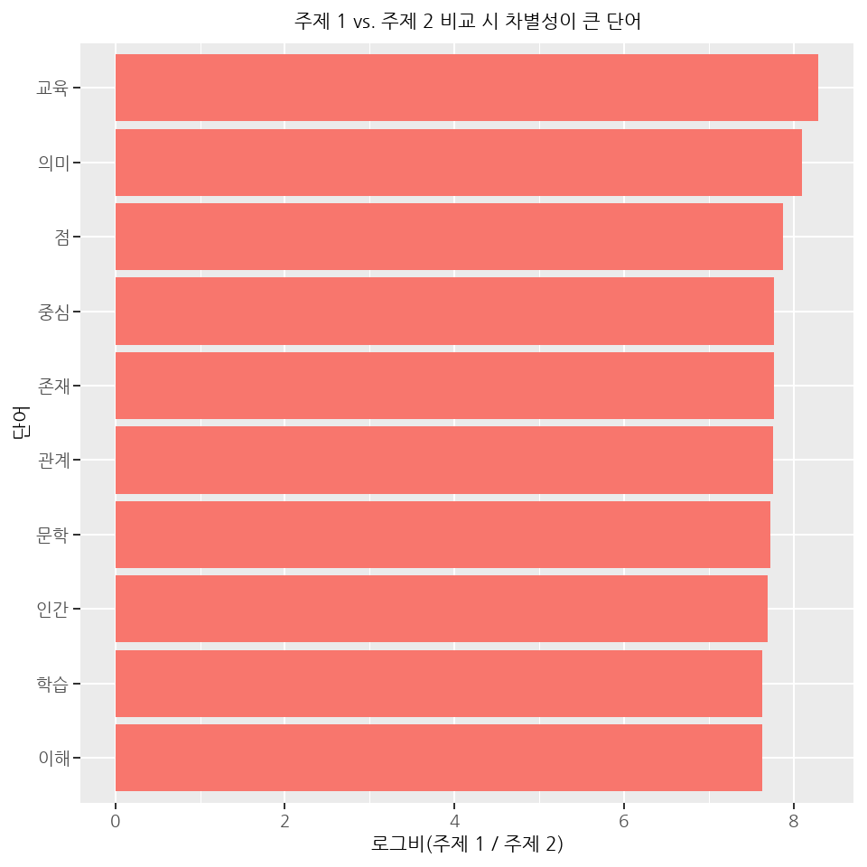

```r
# 예시: topic1 vs. topic2 비교 시 주제별 특징적 단어 10개씩 시각화하기.
top_log_ratio_1_2 %>%
  ggplot(aes(x = reorder(term, log_ratio_1_2), y = log_ratio_1_2, fill = "steelblue")) +
  geom_col(show.legend = FALSE, width = 0.9) + # 범례는 제시하지 않음.
  coord_flip() +
  labs(title = "주제 1 vs. 주제 2 비교 시 차별성이 큰 단어",
       x = "단어", y = "로그비(주제 1 / 주제 2)") +
  theme(text= element_text(family = "NanumGothic"), # 텍스트 폰트 지정하기.
        axis.text.x = element_text(size = 14),  # x축 텍스트 크기.
        axis.text.y = element_text(size = 14),  # y축 텍스트 크기.
        axis.title.x = element_text(size = 16),  # x축 제목 크기.
        axis.title.y = element_text(size = 16),  # y축 제목 크기.
        plot.title = element_text(size = 16, face = "bold", hjust = 0.5) # 그래프 제목 크기 설정하기, 굵게 하기, 가운데 정렬하기.
        )
```

##### 다. 문서-주제 확률

- γ(gamma)
  - 특정 문서가 특정 주제에 할당될 확률: “모든 문서는 주제들이 무작위로 섞인 임의의 혼합물이다.”
  - `matrix` = “gamma”를 지정해주면 주제, 문서, γ 값이 제시됨.

```r
library(broom)
abstract_documents <- tidy(article_lda, matrix = "gamma")
abstract_documents
```

```
## # A tibble: 3,600 × 3
##    document      topic gamma
##    <chr>         <int> <dbl>
##  1 A201008192866     1 0.245
##  2 A201008192914     1 0.144
##  3 A201008192630     1 0.304
##  4 A201008183004     1 0.162
##  5 A201008194895     1 0.159
##  6 A201008193389     1 0.186
##  7 A201008192227     1 0.188
##  8 A201008191392     1 0.160
##  9 A201008193774     1 0.137
## 10 A201008199791     1 0.403
## # ℹ 3,590 more rows
```

```r
# 문서 A201008192866의 주제별 γ 확인하기.
abstract_documents %>%
  filter(document == "A201008192866")
```

```
## # A tibble: 3 × 3
##   document      topic gamma
##   <chr>         <int> <dbl>
## 1 A201008192866     1 0.245
## 2 A201008192866     2 0.541
## 3 A201008192866     3 0.213
```

```r
# DTM 객체 article_dtm_quanteda를 tidy 형식으로 변환하기: 문서의 A201008185934 빈출단어 확인하기.
tidy(article_dtm_quanteda) %>%
  filter(document == "A201008185934") %>%
  arrange(-count)
```

```
## # A tibble: 285 × 3
##    document      term     count
##    <chr>         <chr>    <dbl>
##  1 A201008185934 명화        25
##  2 A201008185934 그림        23
##  3 A201008185934 패러디      23
##  4 A201008185934 텍스트      20
##  5 A201008185934 속          14
##  6 A201008185934 그림책      14
##  7 A201008185934 마그리트    12
##  8 A201008185934 세계        11
##  9 A201008185934 화가        11
## 10 A201008185934 윌리        11
## # ℹ 275 more rows
```

##### 라. 주제 간 거리 기반 네트워크

- 주제 간 유사도를 네트워크 형태로 표현 가능. 이때 연결선의 두께로 유사도 강도 시각화.
- 결과해석 방법
  - 노드: 각 주제.
  - 선(edge): 주제 간 유사도(코사인 유사도).
  - 선의 두께: 유사도가 높을수록 굵음.
  - 노드 간 거리: 유사도가 높을수록 가까움.
  - weight
    - weight는 코사인 유사도로 계산되며, 범위는 0 ~ 1.
    - weight = 1: 완전히 동일한 방향 $\Rightarrow$ 매우 강한 유사성.
    - weight = 0.7: 높은 유사성 $\Rightarrow$ 의미적으로 가까운 주제.
    - weight = 0.3: 낮은 유사성 $\Rightarrow$ 연결은 있지만 약함.
    - weight = 0: 연결 없음 $\Rightarrow$ 보통 그래프에서 제외됨.

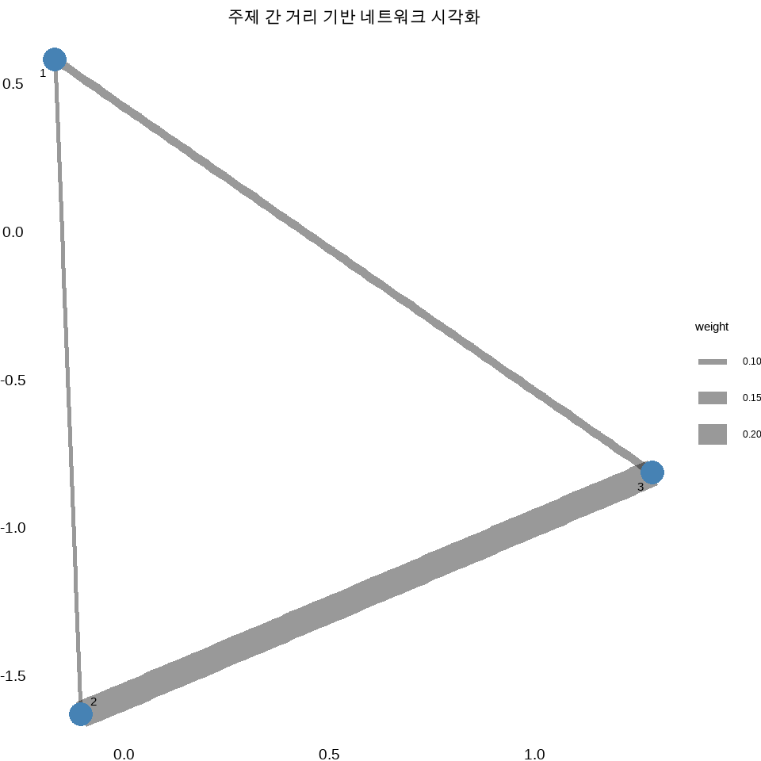

```r
# install.packages(c("ggraph", "igraph", "text2vec"))

library(ggraph) # ggplot 스타일의 네트워크 시각화 패키지.
library(igraph) # 네트워크 객체 생성 및 처리 패키지.
library(text2vec) # 코사인 유사도 계산용 패키지.
library(topicmodels) # posterior() 함수 사용 패키지.

# 1. LDA 모델에서 주제별 단어 분포 행렬 추출하기.
topic_matrix <- posterior(article_lda)$terms
# → 각 주제에 대해 단어별 확률분포를 담은 행렬 생성.
# → 각 주제가 어떤 단어를 얼마나 강하게 포함하고 있는지를 알려줌.
# → 행: 주제, 열: 단어제

# 2. 주제 간 유사도 계산하기(코사인 유사도 사용).
topic_sim <- sim2(topic_matrix, method = "cosine", norm = "l2")
# → sim2()는 행렬 간 유사도를 계산하는 함수.
# 코사인 유사도는 두 벡터의 방향을 비교하는 지표.
# → norm은 벡터 정규화(벡터의 길이를 1로 만드는) 방식을 지정하는 옵션임. L2는 유클리드 거리 기준으로 정규화. 비교하고자 하는 두 벡터의 크기가 제각각이면 비교가 왜곡될 수 있음.
# → 결과는 주제 간 유사도 행렬.

# 3. 유사도 행렬을 기반으로 네트워크 그래프 생성하기.
sim_network_graph <- graph_from_adjacency_matrix(topic_sim, weighted = TRUE, mode = "undirected", diag = FALSE)
# → igraph 객체 생성하기,
# → weighted = TRUE: 유사도를 edge weight로 사용하기.
# → mode = "undirected": 방향 없는 그래프.
# → diag = FALSE: 자기 자신과의 연결은 제거하기.

# 4. 네트워크 시각화
ggraph(sim_network_graph, layout = "fr") +  # layout = "fr": Fruchterman-Reingold 알고리즘(노드 간 거리 최적화용).
  geom_edge_link(aes(width = weight), alpha = 0.4) +  # edge(선)의 두께는 유사도에 비례, 투명도(alpha) 설정하기.
  geom_node_point(size = 5, color = "steelblue") +    # 노드(주제) 점 표시하기.
  geom_node_text(aes(label = name), repel = TRUE) +   # 노드 이름 표시, 겹치지 않게 밀어내기.
  labs(title = "주제 간 거리 기반 네트워크 시각화") +
  theme_void() +                                      # 배경, 축 제거하기(깔끔한 시각화).
  theme(axis.text.x = element_text(size = 14),  # x축 텍스트 크기.
        axis.text.y = element_text(size = 14),  # y축 텍스트 크기.
        plot.title = element_text(size = 16, face = "bold", hjust = 0.5)) # 그래프 제목 크기 설정하기, 굵게 하기, 가운데 정렬하기.
```

#### C. β와 γ 이외의 주요 정보

##### 가. 단어별 주제할당 정보

```r
library(broom)

# quanteda 패키지로 생성한 DTM을 tidy 형식으로 바꾸기.
article_dtm_tidy <- tidy(article_dtm_quanteda)
# → augment() 함수는 tidy 형식 또는 cast_dtm()으로 생성한 DTM만 입력으로 허용.

# augment() 함수로 단어별 주제할당 결과 확인하기.
abs.augment <- augment(article_lda, data = article_dtm_tidy)
abs.augment
```

```
## # A tibble: 79,471 × 4
##    document      term   count .topic
##    <chr>         <chr>  <dbl>  <dbl>
##  1 A201008192866 윤곽선     1      2
##  2 A201008195828 윤곽선     5      2
##  3 A201008192299 윤곽선     1      2
##  4 A201008192866 순열       1      3
##  5 A201008192866 기반       3      2
##  6 A201008192914 기반       1      2
##  7 A201008192227 기반       3      2
##  8 A201008191392 기반       1      2
##  9 A201008199791 기반       1      2
## 10 A201008198198 기반       1      2
## # ℹ 79,461 more rows
```

```r
# 각 주제에서 가장 많이 할당된 상위 단어 10개 추출하기.
top_10_per_topic <- abs.augment %>%
  count(.topic, term, sort = TRUE) %>%
  group_by(.topic) %>%
  slice_max(n, n = 10)
# → 각 주제에서 가장 많이 할당된 단어 추출.
# → 각 주제별 핵심단어를 실제 할당 기반으로 확인.
top_10_per_topic
```

```
## # A tibble: 30 × 3
## # Groups:   .topic [3]
##    .topic term      n
##     <dbl> <chr> <int>
##  1      1 의미    215
##  2      1 사회    193
##  3      1 문제    188
##  4      1 점      178
##  5      1 목적    175
##  6      1 중심    173
##  7      1 과정    167
##  8      1 관계    149
##  9      1 이해    140
## 10      1 중요    139
## # ℹ 20 more rows
```

##### 나. 오차행렬

- 정의: 모형이 학습 후 얼마나 잘 예측을 수행해주는지 그 성능을 측정하기 위해, 예측된 값과 실제 값을 시각적으로 비교한 표.
- 예시: 특정 논문초록에 나오는 단어들이 얼마나 자주 다른 논문초록에 할당되었는지를 보여줌.
- 함수: 빈도측정용 `count()` 함수, 타일 모양으로 오차행렬을 시각화해주는 `geom_tile()` 함수 사용.
- 비율(proportion)
  - 오차행렬은 실제 레이블과 LDA의 예측결과를 비교하여 모형이 얼마나 정확하게 분류했는지를 보여주는 표.
  - **비율**은 각 실제 레이블(행) 기준으로 예측된 주제(열)의 상대적 분포임. $\Rightarrow$ [EX] “실제 레이블 ’인문학’에 속한 문서 중 **몇 퍼센트**가 주제 1로 분류됐는가?”를 의미.
  - 모형의 성공률이라기보다는 **예측의 경향성**을 보여주는 지표.

**[표 3] 예시 오차행렬: 실제 레이블 vs. LDA가 예측한 주제**

| 실제 | 예측 | 빈도 | 비율 |
| --- | --- | --- | --- |
| 공학 | 주제 1 | 60 | 60% |
| 공학 | 주제 2 | 30 | 30% |
| 공학 | 주제 3 | 10 | 10% |
| 인문학 | 주제 1 | 20 | 20% |
| 인문학 | 주제 2 | 70 | 70% |
| 인문학 | 주제 3 | 10 | 10% |
| 의약학 | 주제 1 | 25 | 25% |
| 의약학 | 주제 2 | 25 | 25% |
| 의약학 | 주제 3 | 50 | 50% |

```r
library(tidyverse)
library(yardstick) # 오차행렬 및 분류 평가 지표 계산용.
library(janitor)   # tabyl() 함수로 깔끔한 교차표 생성 및 비율 계산.
library(scales)

# 1. 문서별 주제분포 행렬 추출하기.
gamma <- posterior(article_lda)$topics %>%
  as_tibble() %>% # 행렬을 티블 변환하기.
  mutate(doc_id = article_filtered$doc_id) # 실제 문서 식별자 칼럼 추가하기.

# 2. 가장 높은 확률의 주제를 대표 주제로 선택하기.
gamma_top <- gamma %>%
  pivot_longer(cols = -doc_id,           # doc_id를 제외한 모든 칼럼의 이름에 대해..
               names_to = "topic",       # 이름이 topic인 칼럼을 만들어 그 아래에 해당 칼럼들의 이름(`1`, `2`, `3`..)을 행으로 채워넣어라!
               values_to = "prob") %>%   # doc_id를 제외한 모든 칼럼 밑에 있던 값들은 "prob"이라는 칼럼을 만들어 그 밑에 채워넣어라!
  group_by(doc_id) %>%                   # 문서 단위로 그룹화하기.
  slice_max(prob, n = 1) %>%             # 각 문서별로 가장 높은 확률의 주제 선택하기(주제1 = 10%, 주제2= 70%, 주제3 = 20%일 경우, 주제2 선택).
  ungroup() %>%
  mutate(pred_topic = parse_number(topic))  # topic 칼럼의 행을 숫자로 만들어서 pred_topic라는 제목의 칼럼에 넣어라!

# 3. 실제 레이블과 LDA가 예측한 주제 연결하기.
doc_eval <- article_filtered %>%         # 실제 학술분야 레이블이 담긴 데이터프레임 가져오기.
  select(doc_id, actual_label) %>%       # 문서 식별자와 실제 학술분야 레이블 칼럼만 남기기.
  left_join(gamma_top, by = "doc_id")    # 실제 레이블과 LDA가 예측한 주제 정보 연결하기.

# 4. 오차행렬(교차표 형태) 생성하기.
conf_mat_table <- doc_eval %>%
  tabyl(actual_label, pred_topic) %>%    # 실제 vs. 예측 교차표 생성하기.
  adorn_percentages("row") %>%           # 행 기준 비율(prop) 계산하기.
  adorn_pct_formatting(digits = 1) %>%   # 퍼센트 형식으로 보기 좋게 다듬기.
  adorn_ns()                             # 빈도도 함께 표시하기.
conf_mat_table
```

```
##  actual_label           1           2           3
##          공학  1.8%   (7) 93.2% (373)  5.0%  (20)
##        의약학  7.4%  (30)  7.2%  (29) 85.4% (344)
##        인문학 89.5% (358)  8.2%  (33)  2.2%   (9)
```

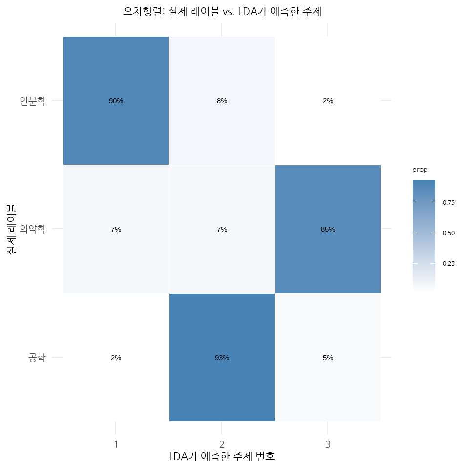

```r
# 5. 오차행렬 시각화를 위해 데이터 변환하기.
conf_mat_plot <- doc_eval %>%
  count(actual_label, pred_topic) %>%    # 실제 vs 예측 빈도 계산하기.
  group_by(actual_label) %>%             # 실제 레이블 기준으로 그룹화하기.
  mutate(prop = n / sum(n)) %>%          # 행 기준 비율 계산하기.
  ungroup()                              # 그룹화 해제하기.

# 6. ggplot2 패키지로 오차행렬 시각화하기.
conf_mat_plot %>%
  ggplot(aes(x = factor(pred_topic), y = actual_label)) + # x축은 pred_topic(숫자에서 요인으로 형식 바꿈), y축은 실제 레이블.
  geom_tile(aes(fill = prop), color = "white") +  # 셀의 내부 색상은 비율(prop)에 따라 채우되, 셀의 경계선은 하얀색으로!
  geom_text(aes(label = scales::percent(prop, accuracy = 1)), size = 4) +  # 셀 안에 퍼센트 표시하기.
  scale_fill_gradient(low = "white", high = "steelblue") + # 셀 색상은 비율이 낮을수록 하얀색 & 높을수록 파란색으로!
  labs(title = "오차행렬: 실제 레이블 vs. LDA가 예측한 주제", # 표 제목 설정하기.
       x = "LDA가 예측한 주제 번호", y = "실제 레이블") + # x축과 y축 제목 설정하기.
  theme_minimal() + # 표의 배경은 미니멀로!
  theme(text= element_text(family = "NanumGothic"), # 텍스트 폰트 지정하기.,
        axis.text.x = element_text(size = 14),  # x축 텍스트 크기.
        axis.text.y = element_text(size = 14),  # y축 텍스트 크기.
        axis.title.x = element_text(size = 16),  # x축 제목 크기.
        axis.title.y = element_text(size = 16),  # y축 제목 크기.
        plot.title = element_text(size = 16, face = "bold", hjust = 0.5)) # 그래프 제목 크기 설정하기, 굵게 하기, 가운데 정렬하기.
```